# Poetry Word Choice Analysis

## Topic Overview

Writing as an art is an expression of creativity. It is a means for escapism, expression, self-realization, and perspective change. Today, computer scientists are trying to map what drives writing and whether creative writing can be emulated by machines.

This project focuses on how creative writing —specifically poetry, where each word is essential— differs from normal language use to understand the implications for a machine learning driven future.

## Questions to Address

1. How does language use by poets differ from normal language use?
2. How does language use differ between poets?
3. What are the common topics explored by poets?
4. How does topic choice differ between poets?
5. How common are poets' topics to average word use?
6. Would LLMs be able to emulate poetry well?

## Dataset Explored

This analysis uses two datasets:

- Poetry Foundation dataset: a collection of poems taken from the Poetry Foundation website; it includes poem, poet, and tag columns. This supports analysis of word frequency, language patterns, and theme frequency.
- Web word frequency dataset: general language frequency from common web usage, used as a baseline for comparison.

These datasets can show how poetic language differs from everyday language.

## Resources

- [Poetry Foundation](https://www.poetryfoundation.org/)
- [More on how a Large Language Model (LLM) works](https://www.ibm.com/think/topics/large-language-models)

## Data Analysis

### Data Set Preparation

This code reads the csv files into dataframes.

```python
import pandas

poetry = pandas.read_csv('../data/PoetryFoundationData.csv')
frequency = pandas.read_csv('../data/unigram_freq.csv')
print("Poetry Data Set Columns:")
print(poetry.columns)
print("Normal Word Frequency Data Set Columns:")
print(frequency.columns)
poetry.head()
```

```
Poetry Data Set Columns:
Index(['Unnamed: 0', 'Title', 'Poem', 'Poet', 'Tags'], dtype='object')
Normal Word Frequency Data Set Columns:
Index(['word', 'count'], dtype='object')
```

|  | Unnamed: 0 | Title | Poem | Poet | Tags |
| --- | --- | --- | --- | --- | --- |
| 0 | 0 | \r\r\n Objects Used to Prop... | \r\r\nDog bone, stapler,\r\r\ncribbage board, ... | Michelle Menting | NaN |
| 1 | 1 | \r\r\n The New Church\r\r\n... | \r\r\nThe old cupola glinted above the clouds,... | Lucia Cherciu | NaN |
| 2 | 2 | \r\r\n Look for Me\r\r\n ... | \r\r\nLook for me under the hood\r\r\nof that ... | Ted Kooser | NaN |
| 3 | 3 | \r\r\n Wild Life\r\r\n ... | \r\r\nBehind the silo, the Mother Rabbit\r\r\n... | Grace Cavalieri | NaN |
| 4 | 4 | \r\r\n Umbrella\r\r\n ... | \r\r\nWhen I push your button\r\r\nyou fly off... | Connie Wanek | NaN |

```python
frequency.head()
```

|  | word | count |
| --- | --- | --- |
| 0 | the | 23135851162 |
| 1 | of | 13151942776 |
| 2 | and | 12997637966 |
| 3 | to | 12136980858 |
| 4 | a | 9081174698 |

This prepares the poetry data set by separating the tags and words in the poem and adding a normalized word count (to correct for dataset size). It also removes all the stop words from both data sets (word like "the").

```python
import string
from sklearn.feature_extraction.text import ENGLISH_STOP_WORDS

poetry["words"] = (poetry["Poem"].str.lower().str.replace(f"[{string.punctuation}]", "", regex=True).str.split())
poetry["words"] = poetry["words"].apply(lambda words: [word for word in words if word not in ENGLISH_STOP_WORDS])
frequency = frequency[~frequency["word"].isin(ENGLISH_STOP_WORDS)]

poetry["word_count"] = poetry["words"].str.len()
poetry["vocab_size"] = poetry["words"].apply(lambda x: len(set(x)))
poetry["normalized_word_count"] = poetry["vocab_size"] / poetry["word_count"]

poetry["tag_list"] = poetry["Tags"].fillna("").str.lower().str.split(",")

poetry.head()
```

|  | Unnamed: 0 | Title | Poem | Poet | Tags | words | word_count | vocab_size | normalized_word_count | tag_list |
| --- | --- | --- | --- | --- | --- | --- | --- | --- | --- | --- |
| 0 | 0 | \r\r\n Objects Used to Prop... | \r\r\nDog bone, stapler,\r\r\ncribbage board, ... | Michelle Menting | NaN | [dog, bone, stapler, cribbage, board, garlic, ... | 59 | 53 | 0.898305 | [] |
| 1 | 1 | \r\r\n The New Church\r\r\n... | \r\r\nThe old cupola glinted above the clouds,... | Lucia Cherciu | NaN | [old, cupola, glinted, clouds, shone, fir, tre... | 57 | 55 | 0.964912 | [] |
| 2 | 2 | \r\r\n Look for Me\r\r\n ... | \r\r\nLook for me under the hood\r\r\nof that ... | Ted Kooser | NaN | [look, hood, old, chevrolet, settled, weeds, e... | 32 | 32 | 1.000000 | [] |
| 3 | 3 | \r\r\n Wild Life\r\r\n ... | \r\r\nBehind the silo, the Mother Rabbit\r\r\n... | Grace Cavalieri | NaN | [silo, mother, rabbit, hunches, like, giant, s... | 74 | 71 | 0.959459 | [] |
| 4 | 4 | \r\r\n Umbrella\r\r\n ... | \r\r\nWhen I push your button\r\r\nyou fly off... | Connie Wanek | NaN | [push, button, fly, handle, old, skin, bones, ... | 53 | 50 | 0.943396 | [] |

```python
frequency.head()
```

|  | word | count |
| --- | --- | --- |
| 26 | new | 1551258643 |
| 32 | home | 1276852170 |
| 37 | page | 1082121730 |
| 40 | search | 1024093118 |
| 41 | free | 1014107316 |

### Question 1 Exploration: How does language use by poets differ from normal language use?

This code creates a normalized ranking (out of one) for both the web and poetry datasets' word frequency. It then plots the poetry's rankings of its top words against the web's rankings, where lower rankings are more common (other than zero).

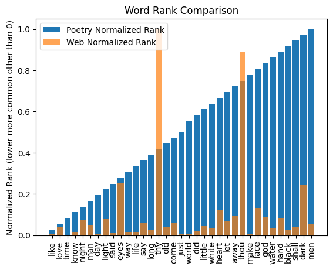

```python
import matplotlib.pyplot as plt
from collections import Counter
import numpy as np

words = [word for words in poetry["words"] for word in words]
word_count = Counter(words)
word_rank_poetry = {word:num for num,(word,_) in enumerate(word_count.most_common(),1)}

#this takes each word, count pairing in the web data set and auto assigns it a rank in a dictionary based on it's sorting from largest to smallest
word_rank_web = {word: rank
    for rank, (word, _) in enumerate(sorted(zip(frequency["word"], frequency["count"]),key=lambda x: x[1], reverse=True), 1)
}

#makes top tag list; I removed the emdash manually because it thought it was a word
top = [word for word,_ in word_count.most_common(36) if '—' not in word]

#this normalizes the ranks from 0 to 1, where 0 is more common
#the normalization is only out of the words shown, the 20 most frequent poetry non-stop words
poetry_ranks = np.array([word_rank_poetry[word] for word in top])
web_ranks = np.array([word_rank_web.get(word, len(word_rank_web)) for word in top])
poetry_ranks = poetry_ranks / poetry_ranks.max()
web_ranks = web_ranks / web_ranks.max()

#plotting bar graph
x = range(len(top))
plt.figure()
plt.bar(x, poetry_ranks, label="Poetry Normalized Rank")
plt.bar(x, web_ranks, alpha=0.7, label="Web Normalized Rank")
plt.xticks(x, top, rotation=90)
plt.ylabel("Normalized Rank (lower more common other than 0)")
plt.title("Word Rank Comparison")
plt.legend()
plt.show()
```

### Question 1 Interpretation:

Poetry and web language are different in word preference. Old words like “thy” and “thou” are common in poetry but rare in web usage. Poetry also tends to emphasize more abstract or sensory language (light, color, emotion). Words like “like,” “said,” and “just” are frequent in both general use and poetry. Thus, poetry favors more expressive and abstract vocabulary while still using some common functional words.

### Question 2 Exploration: How does language use differ between poets?

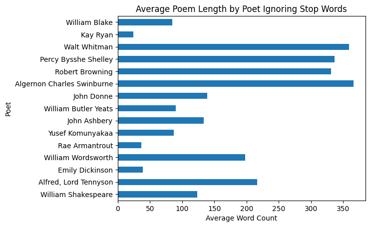

```python
#this creates a dataset that is the poet and the average number of words per poem by aggregating the values
by_poet = poetry.groupby("Poet").agg(poems=("Poem","count"), avg_len=("word_count","mean"),)
by_poet = by_poet.sort_values("poems",ascending=False)
#we take the first 15 poets or so
by_poet = by_poet.head(15)
#this plots the bar graph
plt.figure()
by_poet["avg_len"].plot(kind="barh")
plt.title("Average Poem Length by Poet Ignoring Stop Words")
plt.xlabel("Average Word Count")
plt.show()
```

This plots the most common non-stop words per poet for the first six poets as bar graphs.

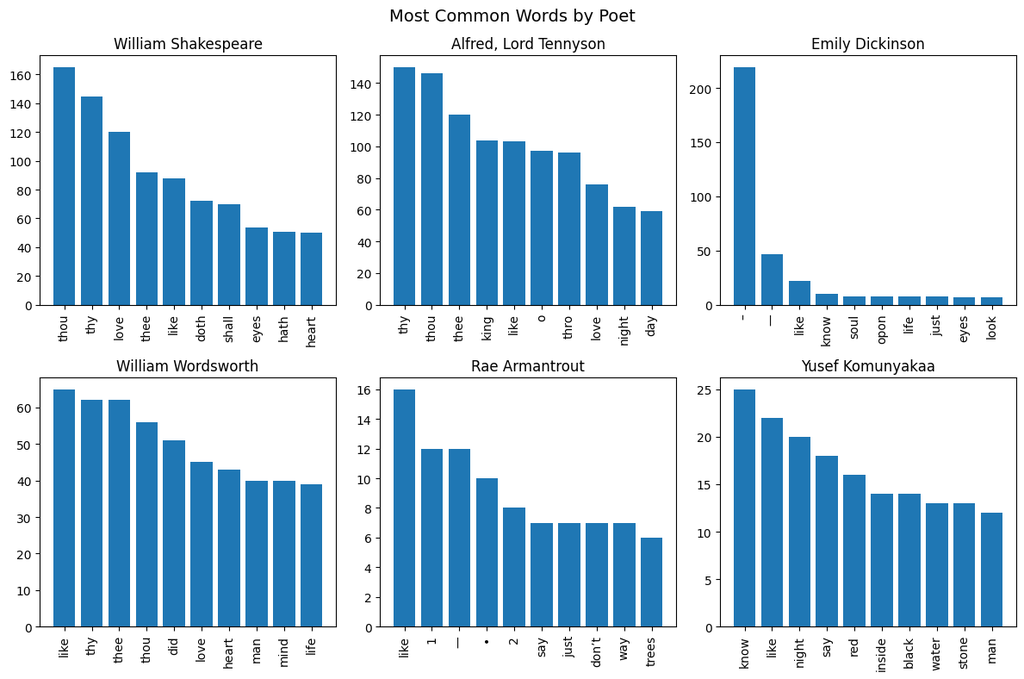

```python
poets = poetry["Poet"].value_counts().head(6).index
fig, axes = plt.subplots(2, 3, figsize=(12, 8))
axes = axes.flatten()

for i, poet in enumerate(poets):

    #gets all the words for this poet (as each poem has a list of words and each poet has multiple poems)
    poet_words = [word for poem in poetry[poetry["Poet"] == poet]["words"]
        for word in poem]

    #word frequency for top ten words
    word_count = Counter(poet_words)
    top_words = word_count.most_common(10)
    words = [word for word, _ in top_words]
    counts = [count for _, count in top_words]

    #plot
    axes[i].bar(words, counts)
    axes[i].set_title(poet)
    axes[i].tick_params(axis="x", rotation=90)

#plot list of bar graphs (all poets)
plt.suptitle("Most Common Words by Poet", fontsize=14)
plt.tight_layout()
plt.show()
```

### Question 2 Interpretation:

The most common words per poet of the poets listed were more similar than I expected. They were mostly focused on common verbs, old words, light, nature, and some punctuation. This is more comparing all the graphs rather than each two to each other. So, there does seem to be an average poet word focus, but the per graph word arrangements are distinct. There are universally common words like "like" but the arrangement of words is distinct.

### Question 3 Exploration: What are the common topics explored by poets?

This plots the 15 most common topics poets write about and how much they're used on a bar graph. The topics are taken from the poetry's initial Tag column.

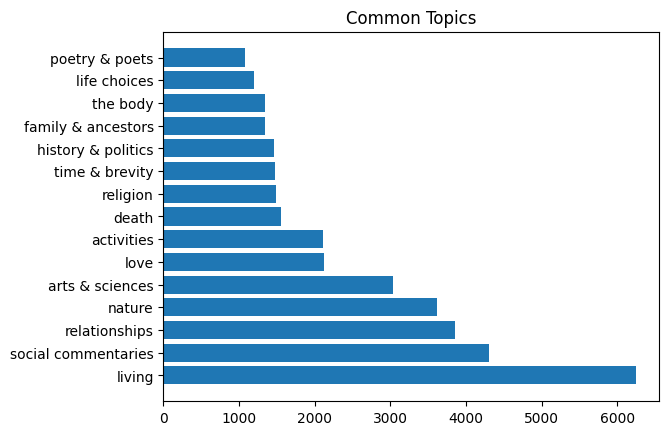

```python
tags = [tag.strip() for row in poetry["tag_list"] for tag in row if tag.strip()]
tag_count = Counter(tags)
common = tag_count.most_common(15)
plt.figure()
tag_types = [x[0] for x in common]
tag_counts = [x[1] for x in common]
plt.barh(tag_types, tag_counts)
plt.title("Common Topics")
plt.show()
```

### Question 3 Interpretation:

Poets are tagged with talking about living more than anything else by far, and then social commentaries, and so on. All of the topics shown are fairly common. This may dissuade the stereotype, the poets are angsty and obsessed with death, though, if living is the most common topic. And this shows the poetry is fairly political in nature, being focused on social commentary.

### Question 4 Exploration: How does topic choice differ between poets?

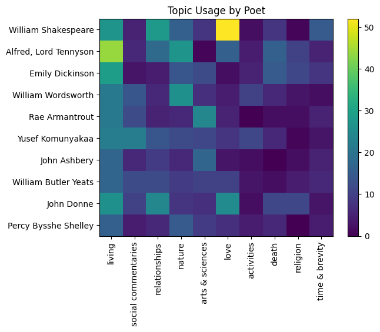

```python
poets = poetry["Poet"].value_counts().head(10).index
top_tags = [tag for tag,_ in Counter(tags).most_common(10)]
data = []
for poet in poets:
    poet_tags = [tag.strip() for row in poetry[poetry["Poet"]==poet]["tag_list"] for tag in row if tag.strip()]
    count = Counter(poet_tags)
    data.append([count.get(tag,0) for tag in top_tags])

plt.figure()
plt.imshow(data, aspect="auto")
plt.xticks(range(len(top_tags)), top_tags, rotation=90)
plt.yticks(range(len(poets)), poets)
plt.title("Topic Usage by Poet")
plt.colorbar()
plt.show()
```

### Question 5 Exploration: How common are poets' topics to average word use?

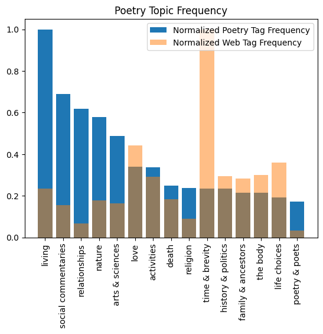

```python
#converts frequency dataset to a a dictionary word:count
web_frequency = dict(zip(frequency["word"], frequency["count"]))

total_web = sum(web_frequency.values())
top_tags = [tag for tag, _ in tag_count.most_common(15)]
tag_scores = []
web_scores = []

#creating poetry tag frequency scores and web tag frequency scores
for tag in top_tags:

    tag_scores.append(tag_count[tag])

    #finding average web frequency for words in the tag
    words_in_tag = tag.split()
    web_score = 0
    valid = 0
    for word in words_in_tag:
        if word in web_frequency and word!='&':
            web_score += web_frequency[word]
            valid += 1
    web_scores.append(web_score / valid if valid > 0 else 0)

#normalizing scores out of one; this is normalized out of the tags shown, not all of them
tag_scores = np.array(tag_scores)
web_scores = np.array(web_scores)
tag_scores = tag_scores / tag_scores.max()
web_scores = web_scores / (web_scores.max() if web_scores.max() > 0 else 1)

#plotting
x = np.arange(len(top_tags))
plt.figure()
plt.bar(x, tag_scores, label="Normalized Poetry Tag Frequency")
plt.bar(x, web_scores, alpha=0.5, label="Normalized Web Tag Frequency")
plt.xticks(x, top_tags, rotation=90)
plt.title("Poetry Topic Frequency")
plt.legend()
plt.show()
```

### Question 5 Interpretation:

The distribution of tag frequencies are fairly dissimilar to each other. Interestingly, out of the tags shown, poetry and the web both have a favorite by far. Poetry favors the living topic, and the web favors time and brevity. The most common poetry topics are not the most common web topics. Essentially, most people care about different things than poets, or at least, write about different things.

Yes and no. LLMs come to a conclusion based on the most probable next chunk of text to occur. There does seem to be an "average" poet; the most common words per poet reoccur frequently (like "like" or "day"), as well as topic - "living" seems to be a commonly used topic for most poets, for instance. However the set of word frequency per poet and favored topics differs. And, there are a lot of topic not tagged that the poets seem to use more than the tagged topics. So I guess I would say LLMs would be able to make something that resembles a poem, but would fail at creating the distinct voice that defines a poet.